# PHYS 481 Assignment 6

October 22, 2019

## Authors:

Siegfried Peschke (30032136) \ Matthew Bouchard (30003689) \ Chris Godek (30030527)

```python
import numpy as np
import matplotlib.pyplot as plt
```

## Problem 1:

Choose some sufficiently large value for the number of electrons $N$. For a range of $\tilde{T}$ and $\tilde{B}$ (sufficiently large to capture the extremal behaviour), write a Python routine to sample (probabilistically) the spin orientations of the electrons, and obtain (and plot) the total energy, the magnetization, and the entropy as a function of $\tilde{T}$ at fixed $\tilde{B}$, for a variety of suitable values of $\tilde{B}$. Interpret your results.

```python
def gen_magnetization(B, T, N):
  return N*np.tanh(B/T)

def gen_energy(B, n1, n2):
  if B < 0:
    return n1 - n2
  else:
    return n2 - n1

def gen_entropy(N, n1, n2):
  return -N*( (n1/N)*np.log(n1/N) + (n2/N)*np.log(n2/N) )
```

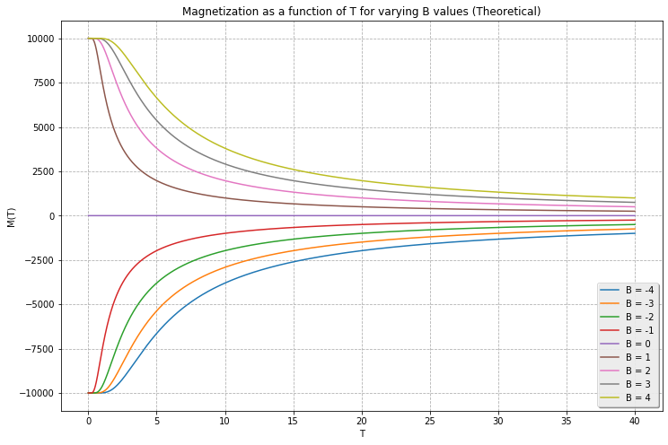

```python
#Plotting Labels
plt.figure(figsize=(12,8))
plt.xlabel('T')
plt.ylabel('M(T)')
plt.title('Magnetization as a function of T for varying B values (Theoretical)')
plt.grid(linestyle='dashed')

#Plot the Function
N = 10000
T_list = np.arange(0.0001, 40, 0.0001)
for B in range(-4,5):
  M_list = []
  for T in T_list:
    M_list.append(gen_magnetization(B, T, N))
  labelname = 'B = ' + str(B)
  plt.plot(T_list, M_list, label = labelname)

#Legend Settings
legend = plt.legend(loc = 4, shadow = 'true')
frame = legend.get_frame()
frame.set_alpha(0.8)
```

From the plot of the magnetization, we can see that as $B$ grows larger, the magnetization takes longer to approach 0.

```python
def gen_probs(B, T):
  p1 = 0.5*(1+np.tanh(B/T))
  p2 = 0.5*(1-np.tanh(B/T))
  return p1, p2

def gen_paramagnet(N, p1, p2):
  return np.random.choice([1,-1], p = [p1, p2], size = N)

def count_spins(magnet):
  count = 0
  for spin in magnet:
    if spin == 1:
      count += 1
  return count, N-count

def calc_M(n1, n2):
  return (n1 - n2)

def calc_U(B, n1, n2):
  if B < 0:
    return n1 - n2
  else:
    return n2 - n1

def calc_S(N, n1, n2):
  return -N*( (n1/N)*np.log(n1/N) + (n2/N)*np.log(n2/N) )

def find_data(N, B, T, finder):
  p1, p2 = gen_probs(B, T)

  magnet = gen_paramagnet(N, p1, p2)

  s_up, s_down = count_spins(magnet)

  if finder == 'M':
    return calc_M(s_up, s_down)

  elif finder == 'U':
    return calc_U(B, s_up, s_down)

  elif finder == 'S':
    return calc_S(N, s_up, s_down)

  else:
    print('Desired value not specified')
    return
```

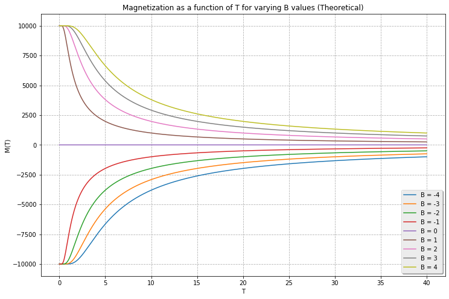

```python
#Plotting Labels
plt.figure(figsize=(12,8))
plt.xlabel('T')
plt.ylabel('M(T)')
plt.title('Magnetization as a function of T for varying B values (Theoretical)')
plt.grid(linestyle='dashed')

#Plot the Function
N = 10000
T_list = np.arange(0.0001, 40, 0.0001)
for B in range(-4,5):
  M_list = []
  for T in T_list:
    M_list.append(gen_magnetization(B, T, N))
  labelname = 'B = ' + str(B)
  plt.plot(T_list, M_list, label = labelname)

#Legend Settings
legend = plt.legend(loc = 4, shadow = 'true')
frame = legend.get_frame()
frame.set_alpha(0.8)
```

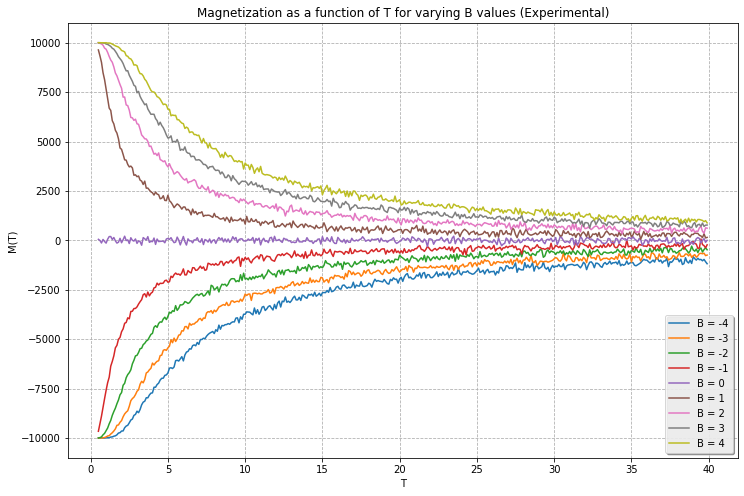

```python
#Plotting Labels
plt.figure(figsize=(12,8))
plt.xlabel('T')
plt.ylabel('M(T)')
plt.title('Magnetization as a function of T for varying B values (Experimental)')
plt.grid(linestyle='dashed')

#Plot the Function
N = 10000
T_list = np.arange(0.5, 40, 0.1)
for B in range(-4,5):
  M_list = []
  for T in T_list:
    M_list.append( find_data(N, B, T, 'M') )
  labelname = 'B = ' + str(B)
  plt.plot(T_list, M_list, label = labelname)

#Legend Settings
legend = plt.legend(loc = 4, shadow = 'true')
frame = legend.get_frame()
frame.set_alpha(0.8)
```

The data matches the theoretical plots for magnetization $\tilde{M}$. As $\tilde{B}$ goes from negative to positive the trend flips from negative magnetization to positive magnetization. We also see that at $\tilde{T} = 0$, the magnetization is $\tilde{M} = N$ which means that at '0' temperature all electrons align in the same direction.

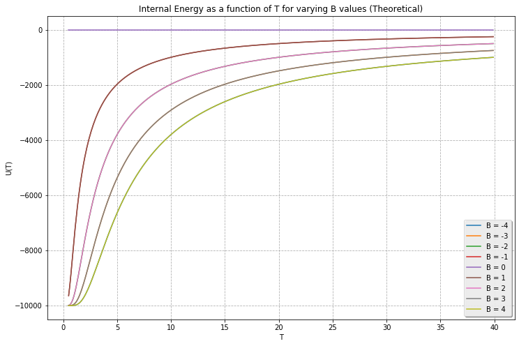

```python
#Plotting Labels
plt.figure(figsize=(12,8))
plt.xlabel('T')
plt.ylabel('U(T)')
plt.title('Internal Energy as a function of T for varying B values (Theoretical)')
plt.grid(linestyle='dashed')

#Plot the Function
N = 10000
T_list = np.arange(0.5, 40, 0.1)
for B in range(-4,5):
  U_list = []
  for T in T_list:
    p1, p2 = gen_probs(B, T)
    n1 = N*p1
    n2 = N*p2
    U_list.append( gen_energy(B, n1, n2) )
  labelname = 'B = ' + str(B)
  plt.plot(T_list, U_list, label = labelname)

#Legend Settings
legend = plt.legend(loc = 4, shadow = 'true')
frame = legend.get_frame()
frame.set_alpha(0.8)
```

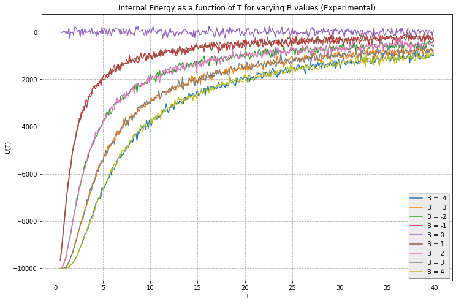

```python
#Plotting Labels
plt.figure(figsize=(12,8))
plt.xlabel('T')
plt.ylabel('U(T)')
plt.title('Internal Energy as a function of T for varying B values (Experimental)')
plt.grid(linestyle='dashed')

#Plot the Function
N = 10000
T_list = np.arange(0.5, 40, 0.1)
for B in range(-4,5):
  U_list = []
  for T in T_list:
    U_list.append( find_data(N, B, T, 'U') )
  labelname = 'B = ' + str(B)
  plt.plot(T_list, U_list, label = labelname)

#Legend Settings
legend = plt.legend(loc = 4, shadow = 'true')
frame = legend.get_frame()
frame.set_alpha(0.8)
```

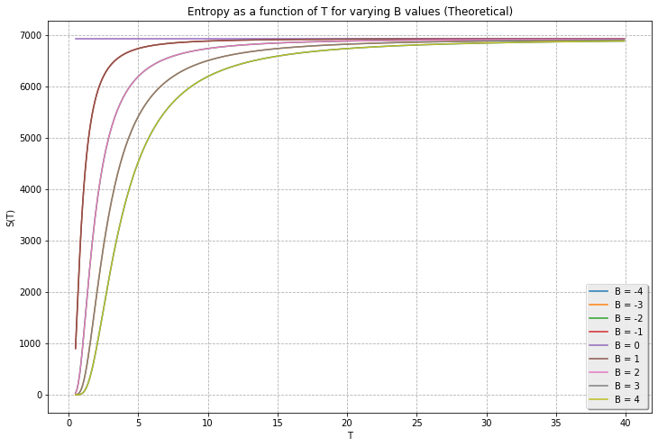

```python
#Plotting Labels
plt.figure(figsize=(12,8))
plt.xlabel('T')
plt.ylabel('S(T)')
plt.title('Entropy as a function of T for varying B values (Theoretical)')
plt.grid(linestyle='dashed')

#Plot the Function
N = 10000
T_list = np.arange(0.5, 40, 0.1)
for B in range(-4,5):
  S_list = []
  for T in T_list:
    p1, p2 = gen_probs(B, T)
    n1 = N*p1
    n2 = N*p2
    S_list.append( gen_entropy(N, n1, n2) )
  labelname = 'B = ' + str(B)
  plt.plot(T_list, S_list, label = labelname)

#Legend Settings
legend = plt.legend(loc = 4, shadow = 'true')
frame = legend.get_frame()
frame.set_alpha(0.8)
```

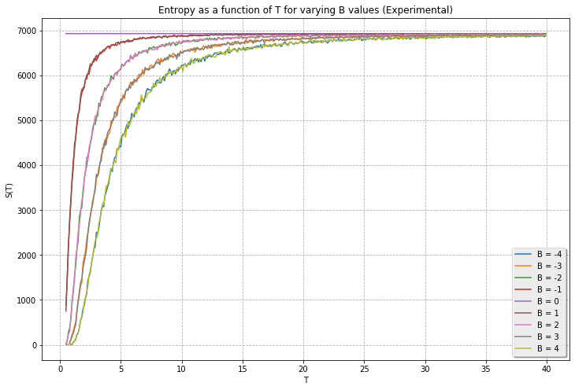

```python
#Plotting Labels
plt.figure(figsize=(12,8))
plt.xlabel('T')
plt.ylabel('S(T)')
plt.title('Entropy as a function of T for varying B values (Experimental)')
plt.grid(linestyle='dashed')

#Plot the Function
N = 10000
T_list = np.arange(0.5, 40, 0.1)
for B in range(-4,5):
  S_list = []
  for T in T_list:
    S_list.append( find_data(N, B, T, 'S') )
  labelname = 'B = ' + str(B)
  plt.plot(T_list, S_list, label = labelname)

#Legend Settings
legend = plt.legend(loc = 4, shadow = 'true')
frame = legend.get_frame()
frame.set_alpha(0.8)
```

The data matches the theoretical plots for internal energy $\tilde{S}$. We see there is a asymptote for the entropy as the temperature gets really large. We expect the asymptote to be the maximum entropy which is $\tilde{S} = \ln({2^N}$) and indeed we see this is true as $N = 10000$ and $\ln({2^N}) \approx 6931$. The larger the value of $\tilde{B}$ the higher the temperature required to reach the asymptote for entropy. At $\tilde{T} = 0$ the entropy is also $\tilde{S} = 0$ which makes sense in accordance to magnetization and internal energy since all aligned electrons will have the minimum entropy.

# Problem 2

Now turn the problem around. Assume now that $N$ and $\tilde{B}>0$ are fixed (so that $\mu_BB$ is simply an energy scale). Now slowly change the value of $p_1$ in the range $0<p_1<1$. Calculate the (dimensionless) Shannon form of the Boltzmann entropy $$\tilde{S}=-N\left[p_1\ln(p_1)+p_2\ln(p_2)\right]$$ and the (dimensionless) total energy $\tilde{U}=\tilde{B}(n_2-n_1)$. Now calculate the (inverse dimensionless) temperature by numerically evaluating the derivative $$\frac{1}{\tilde{T}}=\frac{d\tilde{S}}{d\tilde{U}}.$$ You can compute this derivative numerically by evaluating the finite difference $$\frac{1}{\tilde{T}}\approx \frac{\tilde{S}(p_1+\Delta p_1)-\tilde{S}(p_1)}{\tilde{U}(p_1+\Delta p_1)-\tilde{U}(p_1)}.$$ As long as $\Delta p_1\ll 1$ then this should give a good approximation to the derivative. The advantage of this approach is that you don't need to perform any analytical calculations at all. Again, obtain (and plot) the total energy, the magnetization, and the entropy as a function of $\tilde{T}$ at this fixed $\tilde{B}>0$. Are the results the same as found above?

To start, we will define a function that will compute the derivative of $\tilde{T}$. We can incorporate functions from above for a VERY important reason: The functions above that calculate the (1) total system enegy (U) and (2) system entropy (S) have been GENERALIZED. By this, we mean that the purpose of the generalized function is to compute (1) and (2) using predefined probabilities. As such, we can easily calculate the temperature as described in the pre-amble of this question.

Please note that we have included a value for B in this function simply to signify the BEHAVIOUR of the spin up and spin down electrons. To better understand this, consider if we were to just use the function below without a specified B. If we were to do this we would recieve a range of positive and negative values for the temperature ($\tilde{T}$) - where the negative temperatures are approximately the inverse of the positive. This simply arised due to the influx point being passed (i.e when $P_1=P_2=0.5$). There are two ways that a user may deal with this, they can either (1) limit their plots to only be in the positive x-axis (i.e only positive temperatures)OR they can account for the physical change in the macrostate of the system based on the sign value of $B$. We have chosen to account for the relative energies of the system BEFORE plotting by including this value of B.

```python
def SU_deriv(B, p1, step):
  p2 = 1 - p1

  """

  -- How it Works --

  The purpose of this function is to calculate the temperature for a given change in
  the entropy and total internal energy of the system. It does this by utilizing the
  equations listed above.

  -- Arguments --

  B = Determining the dominant probability (i.e spin up or down)
  p1 = The probability of being in the spin down state
  step = The step size of the function

  """

  magnet0 = gen_paramagnet(N, p1, p2)
  magnet1 = gen_paramagnet(N, p1+step, p2-step)

  s_up0, s_down0 = count_spins(magnet0)
  s_up1, s_down1 = count_spins(magnet1)

  return s_up0, s_down0, (gen_energy(B, s_up1, s_down1) - gen_energy(B, s_up0, s_down0)) / (gen_entropy(N, s_up1, s_down1) - gen_entropy(N, s_up0, s_down0))
```

As such, allow us to plot the derived values of T against the magnetization, energy and entropy of the system. To start allow us to store all the various values associated with our new T_list:

```python
N = 10000
B = 2
step = 0.001
T_list = []
M_list = []
U_list = []
S_list = []
p1_range = np.arange(0,1,step)
for p1 in p1_range:
  s_up, s_down, T = SU_deriv(B, p1, step)
  if T >= 0:
    T_list.append(T)
    M_list.append(gen_magnetization(B, T, N))
    U_list.append(gen_energy(B, s_up, s_down))
    S_list.append(gen_entropy(N, s_up, s_down))
```

And plotting the values yields:

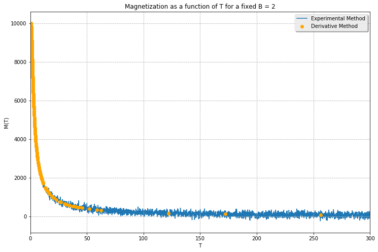

```python
#Plotting Labels
plt.figure(figsize=(12,8))
plt.xlabel('T')
plt.ylabel('M(T)')
plt.title('Magnetization as a function of T for a fixed B = 2')
plt.grid(linestyle='dashed')
plt.xlim(0,300)

#Plot the Function
N = 10000
Temp_list = np.arange(0.5, max(T_list), 0.1)
B = 2
M1_list = []
for T in Temp_list:
  M1_list.append( find_data(N, B, T, 'M') )
plt.plot(Temp_list, M1_list, label = 'Experimental Method',zorder=1)

#Plot the Function
plt.scatter(T_list, M_list, label = 'Derivative Method',color='orange',zorder=2)

#Legend Settings
legend = plt.legend(loc = 1, shadow = 'true')
frame = legend.get_frame()
frame.set_alpha(0.8)
```

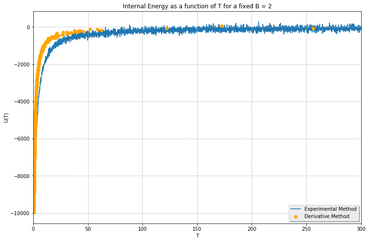

```python
#Plotting Labels
plt.figure(figsize=(12,8))
plt.xlabel('T')
plt.ylabel('U(T)')
plt.title('Internal Energy as a function of T for a fixed B = 2')
plt.grid(linestyle='dashed')
plt.xlim(0,300)

#Plot the Function
N = 10000
Temp_list = np.arange(0.5, max(T_list), 0.1)
B = 2
U1_list = []
for T in Temp_list:
  U1_list.append( find_data(N, B, T, 'U') )
plt.plot(Temp_list, U1_list, label = 'Experimental Method',zorder=1)

#Plot the Function
plt.scatter(T_list, U_list, label = 'Derivative Method',color='orange',zorder=2)

#Legend Settings
legend = plt.legend(loc = 4, shadow = 'true')
frame = legend.get_frame()
frame.set_alpha(0.8)
```

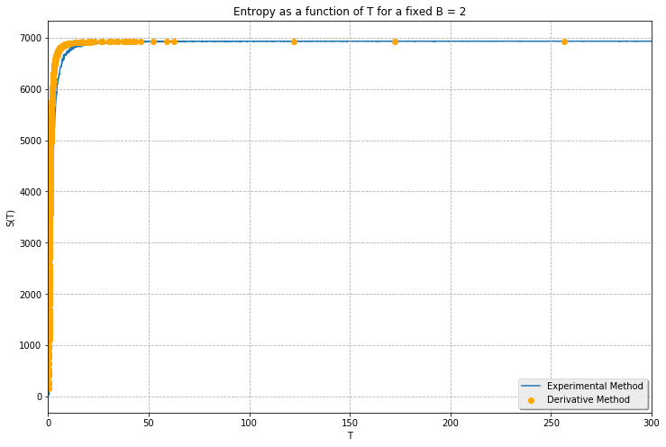

```python
#Plotting Labels
plt.figure(figsize=(12,8))
plt.xlabel('T')
plt.ylabel('S(T)')
plt.title('Entropy as a function of T for a fixed B = 2')
plt.grid(linestyle='dashed')
plt.xlim(0,300)

#Plot the Function
N = 10000
Temp_list = np.arange(0.5, max(T_list), 0.1)
B = 2
S1_list = []
for T in Temp_list:
  S1_list.append( find_data(N, B, T, 'S') )
plt.plot(Temp_list, S1_list, label = 'Experimental Method',zorder=1)

#Plot the Function
plt.scatter(T_list, S_list, label = 'Derivative Method',color='orange',zorder=2)

#Legend Settings
legend = plt.legend(loc = 4, shadow = 'true')
frame = legend.get_frame()
frame.set_alpha(0.8)
```

$$\frac{1}{\tilde{T}}=\frac{d\tilde{S}}{d\tilde{U}}.$$